# Figure 2. Random-forest model detects bacterial taxa that accurately predict indica and japonica subspeciation.

Yong-Xin Liu

2019/2/20

## a. Top features

1. The top 18 bacterial families were identified by applying random-forest classification of the relative abundance of the root microbiota in field II against indica and japonica rice. Biomarker taxa are ranked in descending order of importance to the accuracy of the model. The inset represents 10-fold cross-validation error as a function of the number of input families used to differentiate indica and japonica root microbiota in order of variable importance.

Load RandomForest model for plotting

```r
load("model.RData")
```

### a1. Cross validation

ggplot2 visualize result of cross validation

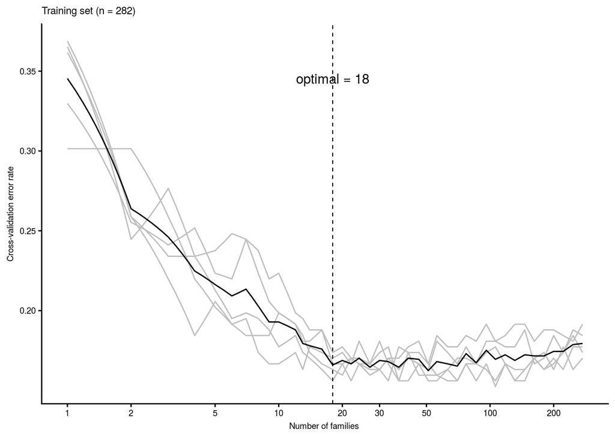

```r
n.var = error.cv$num
error.cv = error.cv[,2:6]
colnames(error.cv) = paste('err',1:5,sep='.')
err.mean = apply(error.cv,1,mean)
allerr = data.frame(num=n.var,err.mean=err.mean,error.cv)
# number of features selected
optimal = 18

write.table(allerr, file = "family_rfcv.txt", sep = "\t", quote = F, row.names = T, col.names = T)

p = ggplot() +
  geom_line(aes(x = allerr$num, y = allerr$err.1), colour = 'grey') +
  geom_line(aes(x = allerr$num, y = allerr$err.2), colour = 'grey') +
  geom_line(aes(x = allerr$num, y = allerr$err.3), colour = 'grey') +
  geom_line(aes(x = allerr$num, y = allerr$err.4), colour = 'grey') +
  geom_line(aes(x = allerr$num, y = allerr$err.5), colour = 'grey') +
  geom_line(aes(x = allerr$num, y = allerr$err.mean), colour = 'black') +
  geom_vline(xintercept = optimal, colour='black', lwd=0.36, linetype="dashed") +
#  geom_hline(yintercept = min(allerr$err.mean), colour='black', lwd=0.36, linetype="dashed") +
  coord_trans(x = "log2") +
  scale_x_continuous(breaks = c(1, 2, 5, 10, 20, 30, 50, 100, 200)) + # , max(allerr$num)
  labs(title=paste('Training set (n = ', dim(otutab_t)[1],')', sep = ''),
       x='Number of families ', y='Cross-validation error rate') +
  annotate("text", x = optimal, y = max(allerr$err.mean), label=paste("optimal = ", optimal, sep="")) +
  main_theme
ggsave(p, file = "family_rfcv.pdf", width = 89, height = 50, unit = 'mm')
p
```

### a2. Features barplot with taxonomy in phylum

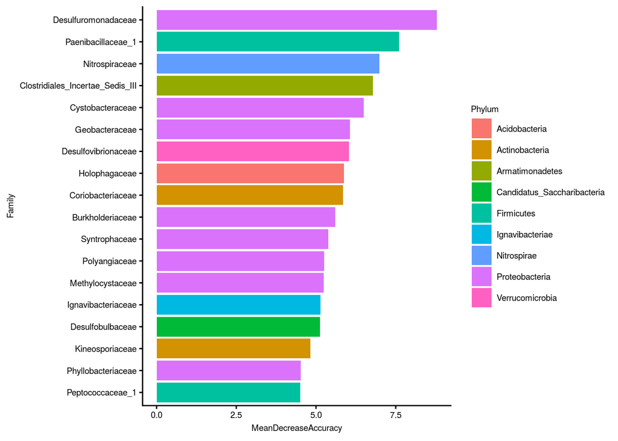

```r
imp = read.table("family_imp_phylum.txt", header=T, row.names= 1, sep="\t")
imp = tail(imp, n = optimal)
imp$Family = factor(rownames(imp), levels = rownames(imp))

p = ggplot(imp, aes(x = Family, y = MeanDecreaseAccuracy, fill = Phylum)) +
  geom_bar(stat = "identity") +
  coord_flip() + main_theme
ggsave(paste("family_top_feautre",".pdf", sep=""), p, width=89 * 1.5, height=50 * 1.5, unit='mm')
p
```

## b. Feature abundance barplot

Data prepare and draw all features abundance in two subspecies

```r
# select randomForest top features
otu_bar = sub_otutab[rownames(imp),]
mean = data.frame(id = rownames(otu_bar), mean=rowMeans(otu_bar))
# Decreasing by mean
mean = arrange(mean, desc(mean))
otu_bar$Family = rownames(otu_bar)
otu_bar = melt(otu_bar, id.vars = "Family")
# head(otu_bar)
design$sampleID = rownames(design)
otu_bar = merge(otu_bar, design[,c("sampleID","subspecies")], by.x="variable", by.y = "sampleID", all.x = T)
# head(otu_bar)

otu_error_bar = summarySE(otu_bar, measurevar="value", groupvars=c("Family","subspecies"))
```

```r
# head(otu_error_bar)

otu_error_bar$Family = factor(otu_error_bar$Family, levels = mean$id)

# p = ggplot(otu_error_bar, aes(x=Family, y=value, fill=subspecies)) +
#   geom_bar(position=position_dodge(), stat="identity") +
#   geom_errorbar(aes(ymin=value-ci, ymax=value+ci),
#                 width=.5,                    # Width of the error bars
#                 position=position_dodge(.9)) + main_theme
# p=p+theme(axis.text.x=element_text(angle=45, vjust=1, hjust=1))
# p
# ggsave(paste("family_errorbar",".pdf", sep=""), p, width=89 * 1.5, height=50 * 2, unit='mm')

DA_list = read.table("f_HTEJ-HIND_all.txt", header=T, row.names=1, sep="\t") # , comment.char=""
DA_list = DA_list[rownames(imp) ,1:5]
DA_list$level = ifelse(DA_list$logFC>0, "Enriched","Depleted")
otu_error_bar = merge(otu_error_bar, DA_list, by.x="Family", by.y = "row.names", all.x = T)
```

### b1. Plot japonica (TEJ) enriched family

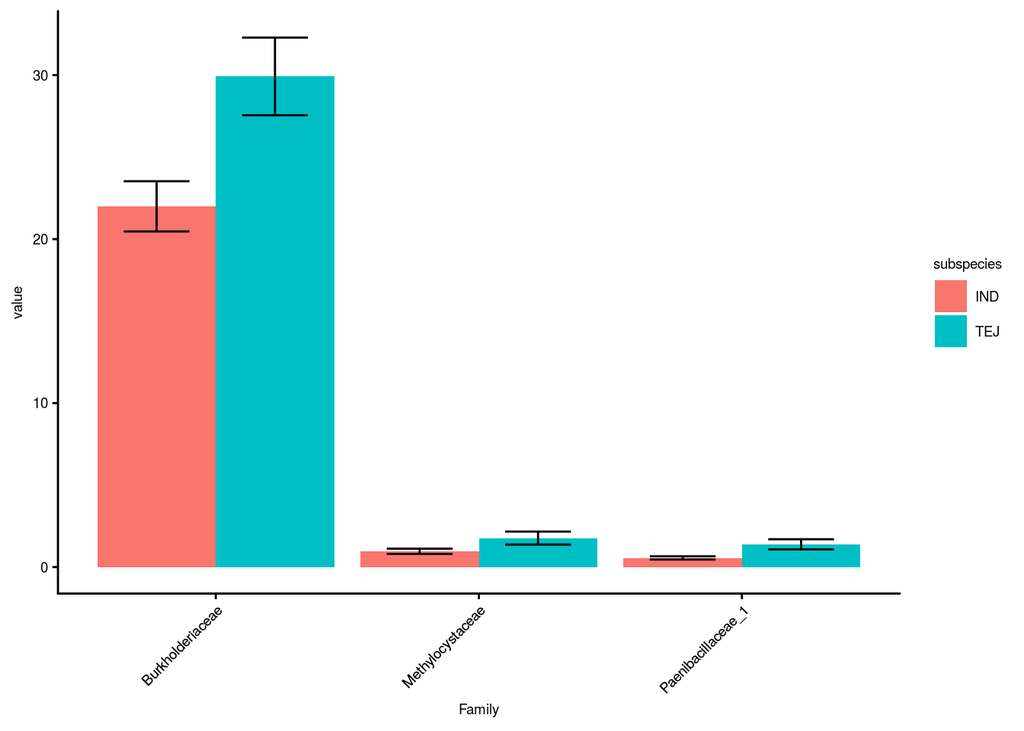

```r
TEJ = rownames(DA_list[DA_list$level == "Enriched",])
p = ggplot(otu_error_bar[otu_error_bar$Family %in% TEJ, ], aes(x=Family, y=value, fill=subspecies)) +
  geom_bar(position=position_dodge(), stat="identity") +
  geom_errorbar(aes(ymin=value-ci, ymax=value+ci),
                width=.5,                    # Width of the error bars
                position=position_dodge(.9)) + main_theme
p=p+theme(axis.text.x=element_text(angle=45, vjust=1, hjust=1))
ggsave(paste("Family_barplot_TEJ",".pdf", sep=""), p, width=89 * 0.6, height=50 * 1.5, unit='mm')
p
```

### b2. Plot indica (IND) enriched family

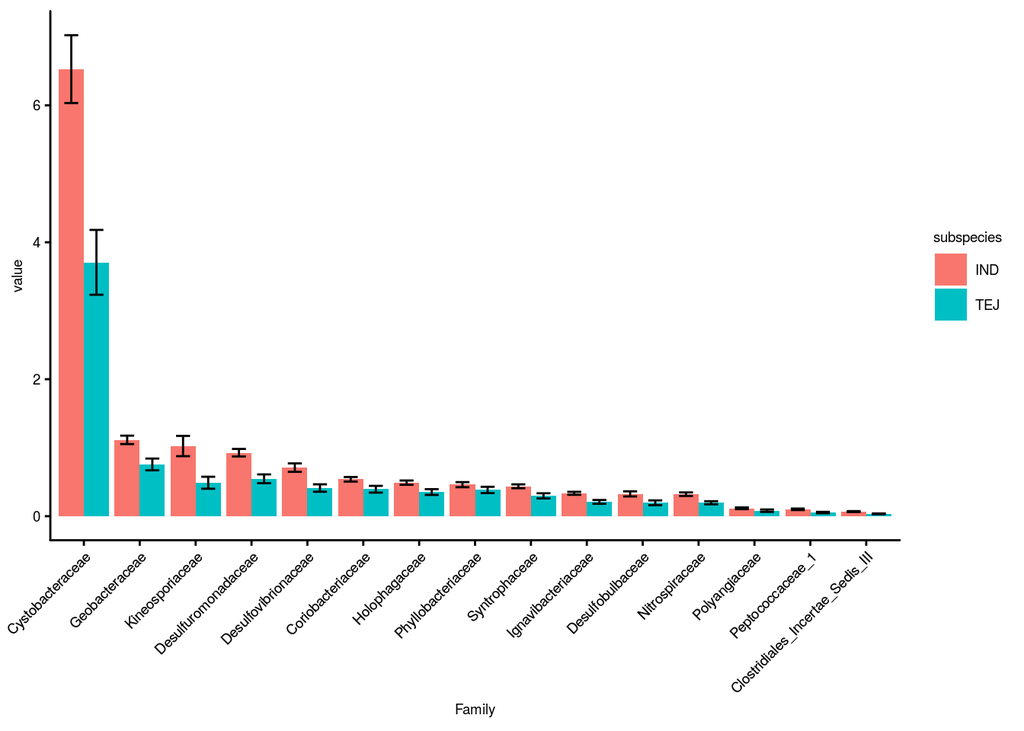

```r
IND = rownames(DA_list[DA_list$level == "Depleted",])
p = ggplot(otu_error_bar[otu_error_bar$Family %in% IND, ], aes(x=Family, y=value, fill=subspecies)) +
  geom_bar(position=position_dodge(), stat="identity") +
  geom_errorbar(aes(ymin=value-ci, ymax=value+ci),
                width=.5,                    # Width of the error bars
                position=position_dodge(.9)) + main_theme
p=p+theme(axis.text.x=element_text(angle=45, vjust=1, hjust=1))
ggsave(paste("Family_barplot_IND",".pdf", sep=""), p,  width=89 * 1.5, height=50 * 1.5, unit='mm')
p
```

## c. Test on Field I

3. The results of prediction of indica and japonica rice in field I according to the random-forest model. Each square represents an individual plant from 68 indica and 27 japonica varieties. The characteristics of the varieties are shown on the left. The predicted characteristics are shown on the right. Indica varieties are shown in red; japonica varieties are shown in blue.

Filed I (LN) as test set

```r
#  Select by manual set group
if (TRUE){
  sub_design = subset(design, group %in% c("LTEJ","LIND"))
  sub_design$group  = factor(sub_design$group, levels=c("LTEJ","LIND"))
}
idx = rownames(sub_design) %in% colnames(otutab)
sub_design = sub_design[idx,]
sub_otutab = otutab[,rownames(sub_design)]
# head(sub_otutab)[,1:10]

otutab_t = as.data.frame(t(sub_otutab))
otutab_t$group = factor(design[rownames(otutab_t),]$subspecies, levels= c("TEJ","IND"))

# apply model on test set
set.seed(315)
library(randomForest)
otutab.pred = predict(otutab_t.rf, otutab_t )
pre_tab = table(observed=otutab_t[,"group"], predicted=otutab.pred)
pre_tab
```

```
##         predicted
## observed TEJ IND
##      TEJ  62  18
##      IND  11 190
```

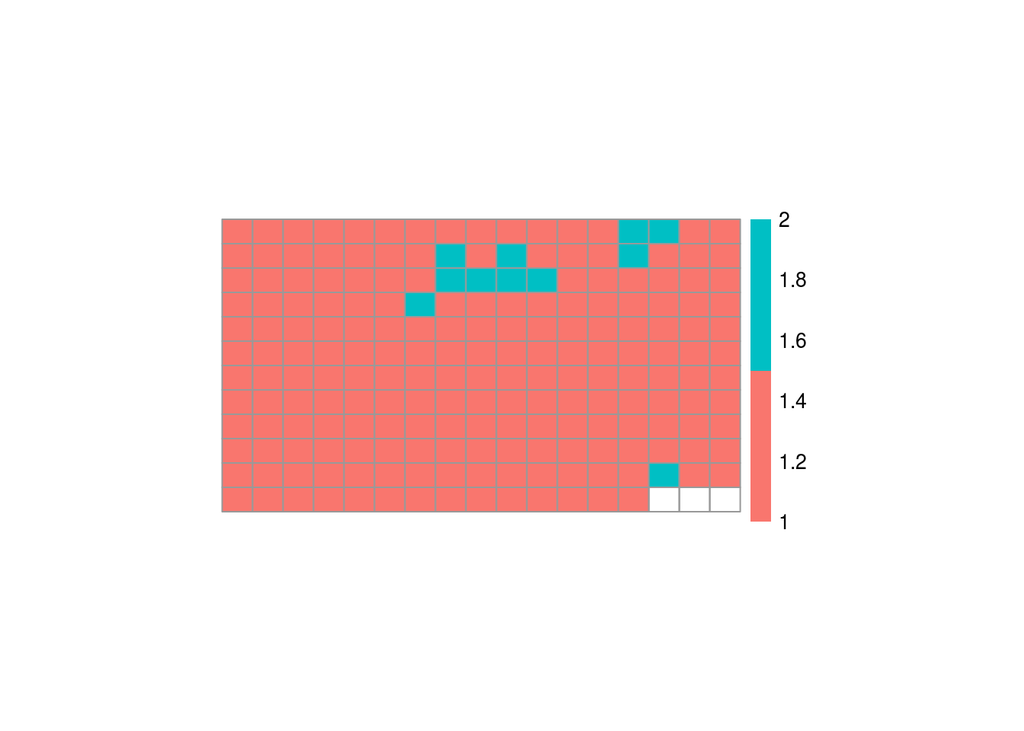

```r
# save prediction result
predict = data.frame(group = otutab_t[,"group"], predicted=otutab.pred)
write.table(predict, file = "RF_prediction_FieldILN.txt", quote = F, row.names = T, col.names = T, sep = "\t")
system("sed -i 's/group/ID\tsubspecies/;s/IND/indica/g;s/TEJ/japonica/g' RF_prediction_FieldILN.txt")

# visualize prediction result by heatmap
predict$result = ifelse(predict$group == predict$predicted, 1, 0)
predict$predict = ifelse(predict$predicted == "IND", 1, 2)
column = 17

IND = predict[predict$group=="IND",]$predict
row = round(length(IND)/column + 0.5)
i = column * row - length(IND)
IND = c(IND, rep(NA, i))
matrix = matrix(IND, nrow = row, ncol = column, byrow = T)
pheatmap(matrix, color = c("#F9766E", "#00BFC4") , cluster_rows = F, cluster_cols = F, cellwidth = 15, cellheight = 12,
         filename = "family_test_IND.pdf")
pheatmap(matrix, color = c("#F9766E", "#00BFC4") , cluster_rows = F, cluster_cols = F, cellwidth = 15, cellheight = 12)
```

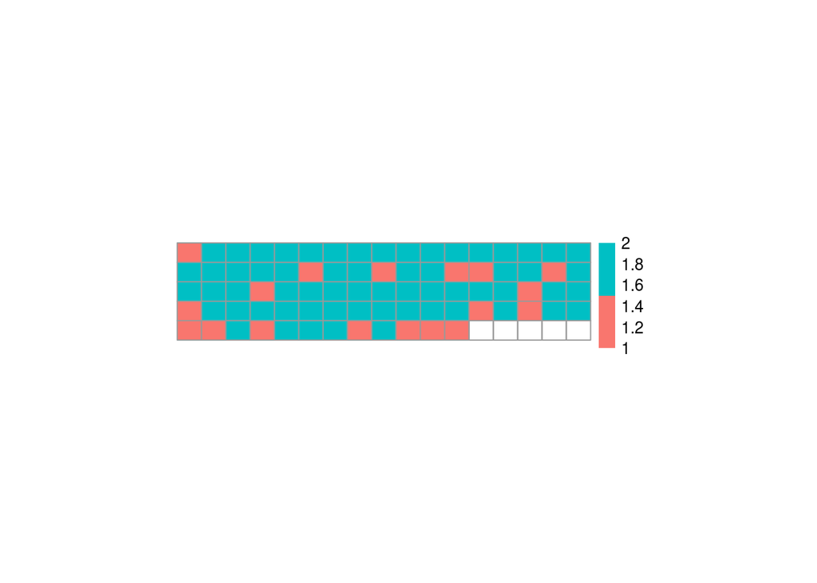

```r
TEJ = predict[predict$group=="TEJ",]$predict
row = round(length(TEJ)/column + 0.5)
i = column * row - length(TEJ)
TEJ = c(TEJ, rep(NA, i))
matrix = matrix(TEJ, nrow = row, ncol = column, byrow = T)
pheatmap(matrix, color = c("#F9766E", "#00BFC4") , cluster_rows = F, cluster_cols = F, cellwidth = 15, cellheight = 12,
         filename = "family_test_TEJ.pdf")
pheatmap(matrix, color = c("#F9766E", "#00BFC4") , cluster_rows = F, cluster_cols = F, cellwidth = 15, cellheight = 12)
```

## d. Test on new varieties grown in new locations

4. The results of prediction of indica and japonica varieties that were not included in the training set and were grown in different geographical locations, according to the random-forest model. Each square represents an individual plant from tested varieties. The number of biological replicates in this figure is as follows: in field I, indica (n = 201), japonica (n = 80); in field II, indica (n = 201), japonica (n = 81).

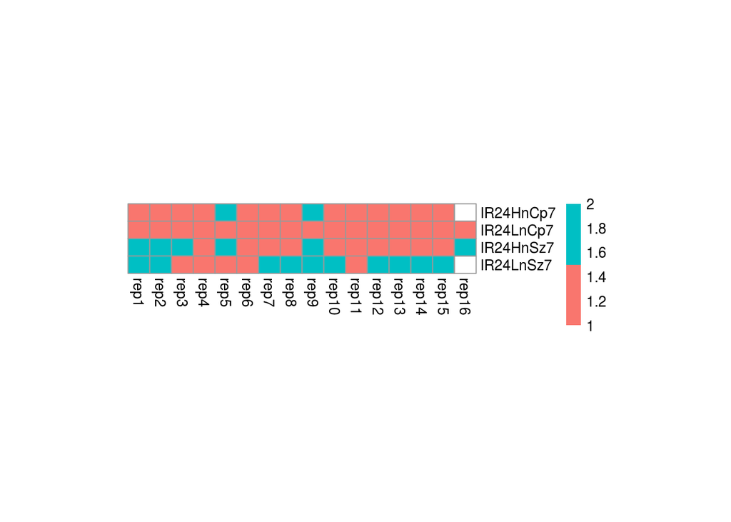

```r
# Select IR24(indica) and ZH11(japonica) grow in Changping and Shangzhuang Farm (include Ln and Hn two field).
grouplist = c("IR24HnCp7", "IR24LnCp7", "IR24HnSz7", "IR24LnSz7", "ZH11HnCp7", "ZH11LnCp7", "ZH11HnSz7", "ZH11LnSz7")
design_sub = subset(design, groupID %in% grouplist)

predict = matrix(0, ncol = 8, nrow = 17)
colnames(predict) = grouplist
column = 17

for(i in 1:length(grouplist)) {
  #i = 1
  design_sub2 = subset(design_sub, groupID %in% grouplist[i])
  idx = rownames(design_sub2) %in% colnames(otutab)
  design_sub2 = design_sub2[idx,]
  otutab_sub = otutab[,rownames(design_sub2)]
  otutab_sub=as.data.frame(t(otutab_sub))
  #otutab_sub$group = as.vector(design_sub2$subspecies)
  set.seed(315)
  otutab.pred = predict(otutab_t.rf, otutab_sub)
  otutab.pred
  levels(otutab.pred) = c(2, 1)
  j = column - length(otutab.pred)
  predict[, i]= c(as.vector(otutab.pred), rep(NA, j))
}
matrix = matrix(as.numeric(predict), ncol = 8, nrow = 17)
colnames(matrix) = grouplist
matrix = t(matrix)
colnames(matrix) = paste("rep", 1:17, sep = "")

write.table(matrix, file = "RF_predict_test2.txt", quote = F, row.names = T, col.names = T, sep = "\t")
system("sed -i 's/rep1/ID\trep1/;s/\t1/\tindica/g;s/\t2/\tjaponica/g' RF_predict_test2.txt")


# pheatmap(matrix, color = c("#F9766E", "#00BFC4") , cluster_rows = F, cluster_cols = F, cellwidth = 15, cellheight = 12)
pheatmap(matrix[1:4, 1:16], color = c("#F9766E", "#00BFC4") , cluster_rows = F, cluster_cols = F, cellwidth = 15, cellheight = 12,
         filename = "family_test_nrt_IND.pdf")
pheatmap(matrix[1:4, 1:16], color = c("#F9766E", "#00BFC4") , cluster_rows = F, cluster_cols = F, cellwidth = 15, cellheight = 12)
```

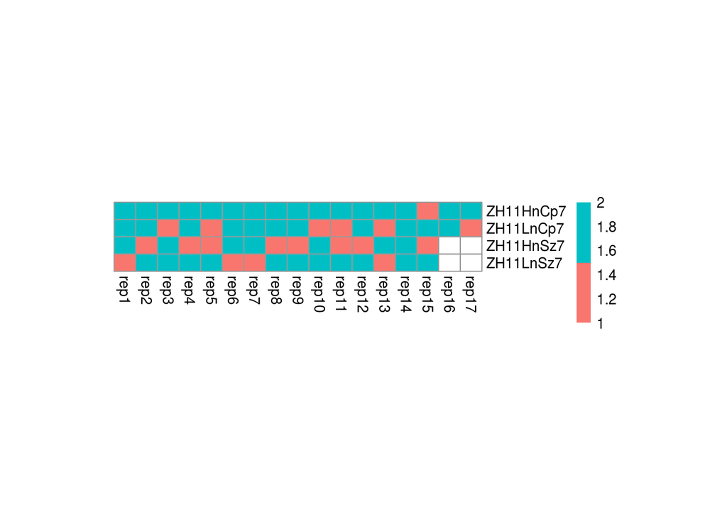

```r
pheatmap(matrix[5:8,], color = c("#F9766E", "#00BFC4") , cluster_rows = F, cluster_cols = F, cellwidth = 15, cellheight = 12,
         filename = "family_test_nrt_TEJ.pdf")
pheatmap(matrix[5:8,], color = c("#F9766E", "#00BFC4") , cluster_rows = F, cluster_cols = F, cellwidth = 15, cellheight = 12)
```